# Combating Gerrymandering Through Non-Geographic Visualizations

### Using models of distortion to emphasize partisanship in map drawing

Xavier Adomatis

## Data Background

- Historical data (2004-2020) drawn from wikipedia via wayback machine scraping.
  - Neither Cook or National Journal's paid subscriptions offer data repositories inclusive of redrawn districts.
- 2022 projections data breakdown:
  - 45 states drawn from Dave's Redistricting (semi-open source)
  - 5 states drawn from 538 and reverse engineered
    - FL due to recency of passage
    - WV and KY due to data gaps
    - NH and MO due to maps not being finalized
- Issues with data quality preclude API usage

## Data Quirks

- Incomplete maps: MO and NH
  - Data draws on the highest passed/not vetoed proposals
- Legally fluctuating maps: NY and KS
  - Both maps are headed to state supreme courts in the next two weeks for validity
- Temporary maps: NC
  - Map will be invalid in the 2024 cycle

## Methodology for Fairness

#### Compare the expected value of Congressional Representation with the state's share of voters

- States with neutral ratings have better porportionality
- Porportionality can mean two things:
  - A state can emphasize competitive districts (i.e. New Hampshire's 2012-2020 map)
  - A state can cut polarized districts porportional to its population (i.e. Maine's 2012-2020 map)
  - A more polarized state can mix the methods, like Iowa
- Using expected value in a model is better than other metrics (median seat and wasted votes) because it accounts for the steep jump between PVIs
  - If an R+5 state like Texas had 38 R+5 congressional districts, it would score fairly under all other metrics; however, this would result in 80% of the Congressional seats being Republican, excluding much of the 47.5% of the Democrating population
- PVI is the fundamental basis point because it ignores incumbent advantages but still accounts for Congressional outperformance of presidential parties (especially for the GOP)

## Methodology for Predictions

- Because we have the data, we can machine learn on the last 9 Congressional cycles (~4,000 elections) as the training set and test based on the 2022 map
- if we train on wave years (2006, 2008, 2010, 2014, and 2018) we have a narrower training set but are still roughly able to capture new relationships with PVI

## Prediction Methodology Explained

#### Raw Averages on waves

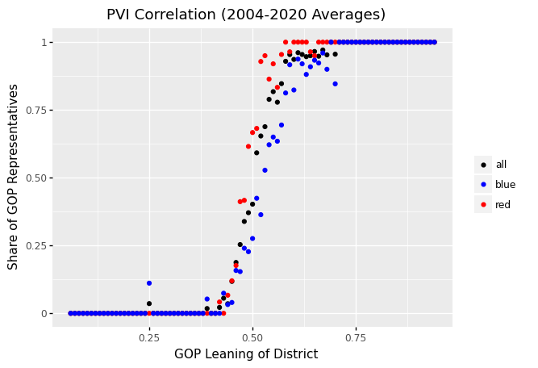

- All-years averaged is basically contiuous
- Wave models are significantly less so, with R+9's more likely to be Democratic than R+7's
- Mildly Democratic districts are more immune to waves than GOP mildly districts
- Machine learning is necessary to account for these differences

#### Logit on waves

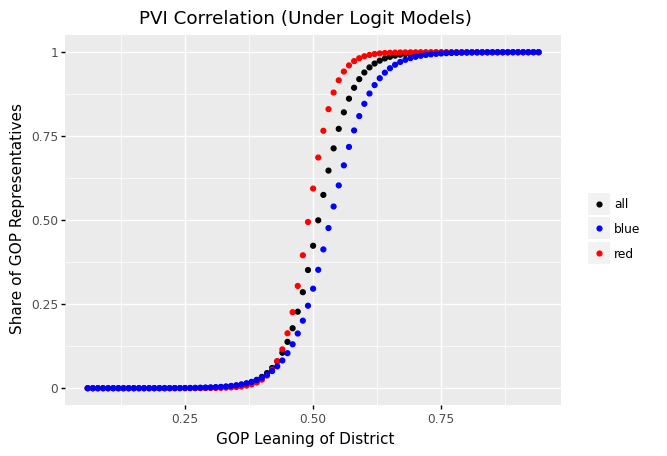

- Accounts for the disporportionate impact of waves on 'likely' districts, especially for GOP leaning districts
- Ideally this would be tested on SVMs as well, but probability extraction seems to be impossible

## Cartogram

```python
Cartogram
```

[interactive chart not shown]

- Highlights states with suprisingly high levels of distortion, especially those with few districts
- Allows users to see their own state's misrepresentation

## Bubble Chart

```python
Bubble
```

[interactive chart not shown]

- Highlights impact of distortion when weighted as Congressional districts impacted
- Shows distortion is concentrated in small red states but biggest district shifts are in blue states

## Wave Prediction Models

- Plots that use logit predictions to examine possible outcomes on the 2022 map
- Also works on historical datasets; test runs have shown approximate outcomes
  - Mostly due to model training on those years

```python
get_viz(2022,"All","Majority")
```

[interactive chart not shown]

```python
get_viz(2022,"All","Median")
```

[interactive chart not shown]

```python
get_viz(2022,"Democratic","Majority")
```

[interactive chart not shown]

```python
get_viz(2022,"Democratic","Median")
```

[interactive chart not shown]

```python
get_viz(2022,"Republican","Majority")
```

[interactive chart not shown]

```python
get_viz(2022,"Republican","Median")
```

[interactive chart not shown]

Questions? Advice?